# Final project: Ask a Manager Analysis

Study Group 6

# Introduction

In this report, we will be looking at the “Ask a Manager” 2021 survey and focusing on the influencing factors of salaries.

# Table of contents

## I. Cleaning the dataset

a.Salary b.Gender c. Purchase Power Parity (PPP) d.Industries e. Race

## II. Analysis of Salaries

1. Purchasing Power Parity adjusted Salary
2. Focus on the United States

## III. Linear Regression Models

```r
# use googlesheets4 to get data

url <- "https://docs.google.com/spreadsheets/d/1IPS5dBSGtwYVbjsfbaMCYIWnOuRmJcbequohNxCyGVw/edit?resourcekey#gid=1625408792"
googlesheets4::gs4_auth() # google sheets authorisation
```

```
## ! Using an auto-discovered, cached token.
```

```
##   To suppress this message, modify your code or options to clearly consent to
##   the use of a cached token.
```

```
##   See gargle's "Non-interactive auth" vignette for more details:
```

[output not shown]

```r
# load "Ask a A Manager 2021 Survey" googlesheet
# https://www.askamanager.org/
ask_a_manager_2021 <- googlesheets4::read_sheet(url) %>%
  janitor::clean_names()
```

```
## ✓ Reading from "Ask A Manager Salary Survey 2021 (Responses)".
```

```
## ✓ Range 'Form Responses 1'.
```

# I. Cleaning the Data

## a. Salary

For the sake of simplicity, we first bring together all monetary compensations: base salaries and “other monetary compensations” - simply put, bonuses. We then convert all currencies to USD, to have a ground for comparison.

```r
clean_data1 <- ask_a_manager_2021%>%
  drop_na(industry)%>%
select(-"additional_context_on_job_title") %>%
select(-"additional_context_on_income")%>%
select(-"currency_other")%>%
select(-"state")%>%
select(-"city")

clean_data1$other_monetary_comp[is.na(clean_data1$other_monetary_comp)]= 0
clean_data2 <- clean_data1 %>%
  mutate(other_monetary_comp = as.numeric(replace(other_monetary_comp, which(other_monetary_comp == "NULL"), 0)))
clean_data3 <- clean_data2 %>%
  mutate(total_salary = other_monetary_comp + annual_salary)

# exchange different currency to new column, named USD_exchange
## write a function to convert currency
 currencyCon <- function(x,from = "USD", to = "EUR"){
   values<-c(1.00,0.92,0.81,1.27)
   names(values)<-c("USD","EUR","GBP","CAD")
   values[to]/(values[from]/x)
 }

## apply the function and create a new column
clean_data4 <- clean_data3 %>%
  mutate(USD_exchange = currencyCon(clean_data3$total_salary, clean_data3$currency, "USD"))

clean_data5 <- clean_data4 %>%
  mutate(country=countryname(country,'iso3c'))%>%
  drop_na(country)
```

## b. Gender

```r
ppp_data1 <- read_csv(here::here("data","pppdata.csv"))
ppp_data2 <- ppp_data1 %>%
  filter(TIME == "2020")

ppp_data3<-ppp_data2[!(ppp_data2$LOCATION=="EU27_2020" | ppp_data2$LOCATION=="EA19"),]
```

## c. Purchase Power Parity

We then join the purchase power parity (PPP) data to our dataset and create a new value, “PPP Salary”. We look at the purchasing power parity adjusted salary to have a ground for comparison when looking at all countries, as $1 in one country is not worth as much in another.

```r
ppp_data4 <- ppp_data3 %>%
  select(LOCATION, Value)
merge_data <- left_join(clean_data, ppp_data4, by = c('country' = 'LOCATION'))

ppp_data<- merge_data %>%
  mutate(ppp_salary = total_salary / Value) %>%
filter(!is.na(Value))

ppp_data<- merge_data %>%
  mutate(ppp_salary = total_salary / Value) %>%
  filter(!is.na(Value))
```

## d. Industries

We create new industries attribution, as the survey’s respondents phrased their industries in many different ways. We then filter out industries for which there was not enough observations.

```r
library(stringr)
#
# filter(ppp_data, str_detect(industry, "Pharmaa*"))
# ppp_data %>%
#   filter(str_detect(industry,"profa*"))

# str_view(ppp_data$industry,"^Edua*")

ppp_data5 <- ppp_data %>%
  mutate(
    industry = case_when(
     str_detect(ppp_data$industry, "^Acaa*") ~ "Academia",
     str_detect(ppp_data$industry, "pharmaa*") ~ "Pharmaceuticals",
     str_detect(ppp_data$industry, "Pharmaa*") ~ "Pharmaceuticals",
     str_detect(ppp_data$industry, "^Accounta*") ~ "Accounting, Banking & Finance",
    str_detect(ppp_data$industry, "profa*") ~ "Nonprofits",
    TRUE ~ industry
    )
  )

ppp_data_industry <-  ppp_data5 %>%
  count(industry,sort=TRUE) %>%
  mutate(percent=100* n/sum(n)) %>%
  filter(percent>1)

ppp_industry <- ppp_data_industry$industry

ppp_data_clean <- ppp_data %>%
  filter(industry %in% ppp_industry)
```

## e. Race

We will now clean our race column. If we run a `unique` function in r on the race column we see that there are 44 different categories. We will separate the races into white, non white and unanswered. We then take out the Not Answered values as can be seen in the code below.

```r
ppp_data_final_clean <- ppp_data_clean %>%
  drop_na(race, USD_exchange, highest_level_of_education_completed) %>%
  mutate(
    race_filtered = case_when(
    str_detect(race, "^Whitea*") ~ "White",
    str_detect(race, "Another option not listed here or prefer not to answer*") ~ "Not Answered",
    TRUE ~ "Non White"
    )
  ) %>%
  filter(!race_filtered=="Not Answered")
```

# II. Analysis of salary differences

To begin with our analysis, we will look at the number of responses by industries.

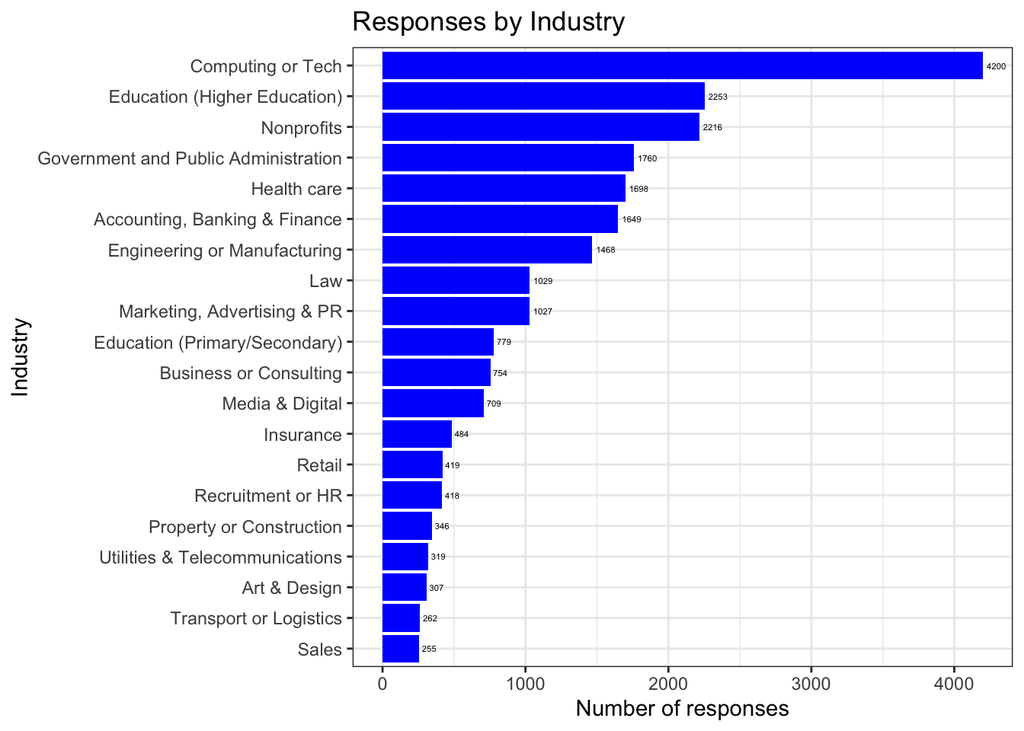

```r
ppp_data_clean %>%
  drop_na(industry) %>%
  group_by(industry) %>%
  summarise(Freq = n()) %>%
  ggplot(aes(fct_reorder(industry, Freq),Freq)) +
  geom_bar(stat = "identity", fill = "blue") +
  geom_text(aes(label = Freq), position = position_dodge(width = 1), hjust = -0.2, size = 1.5) +
  coord_flip() +
  xlab("Industry") +
  ylab("Number of responses") +
  ggtitle("Responses by Industry") +
  theme_bw()
```

```r
# ggplot(ppp_data_clean, aes(x=ppp_salary))+
# geom_point()
```

## a. Purchasing Power Parity adjusted Salary

### Purchasing Power Parity adjusted Salary by Industry

```r
#Average ppp_salary worldwide by industry
library(scales)
```

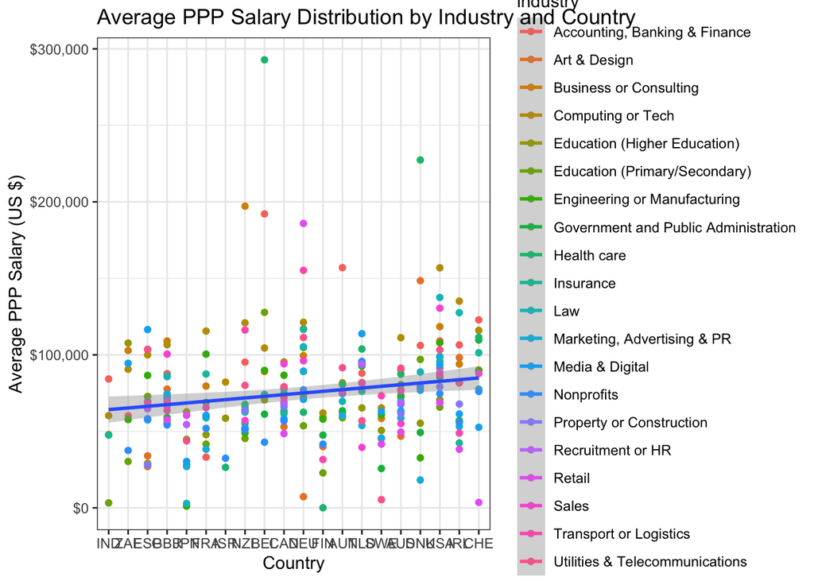

```r
plot5<-ppp_data_clean%>%
  select(industry,country,ppp_salary)%>%
  group_by(country,industry)%>%
  summarise(mean3=mean(ppp_salary))
big_country <- ppp_data_clean %>%
  count(country, sort = TRUE) %>%
  mutate(percent = 100*n/sum(n)) %>%
  filter(percent >0.05)

big_country_list <- big_country$country
plot6 <- plot5 %>%
  filter(country %in% big_country_list)



# create list of gdp per capita of each country
   values<-c(57447,53265,47607,48137,84987,49548,62709,32026,52131,43959,42915,2338,81315,45958,43597,55606,46278,56763,66678,6441)
   names<-c("AUS","AUT","BEL","CAN","CHE","DEU","DNK","ESP","FIN","FRA","GBR","IND","IRL","ISR","JPN","NLD","NZL","SWE","USA","ZAF")

gdp_list <- do.call(rbind, Map(data.frame, A = values, B = names))
colnames(gdp_list) <- c("gdp", "country")

# merge gdp list with origional data
plot7 <- left_join(plot6, gdp_list, by = "country")

# plot with both scatter point and smooth line, x axis is ordered by GDP per capita
plot7%>%
    ggplot(aes(x=reorder(country, gdp),y=mean3,group=1,color=industry))+
  geom_point()+
  geom_smooth(method=lm)+
  scale_y_continuous(labels = dollar)+
  labs(title = "Average PPP Salary Distribution by Industry and Country",
       x="Country",
       y= "Average PPP Salary (US $)")+
   theme(axis.text=element_text(size=8),
        axis.title=element_text(size=10))+
  theme_bw()
```

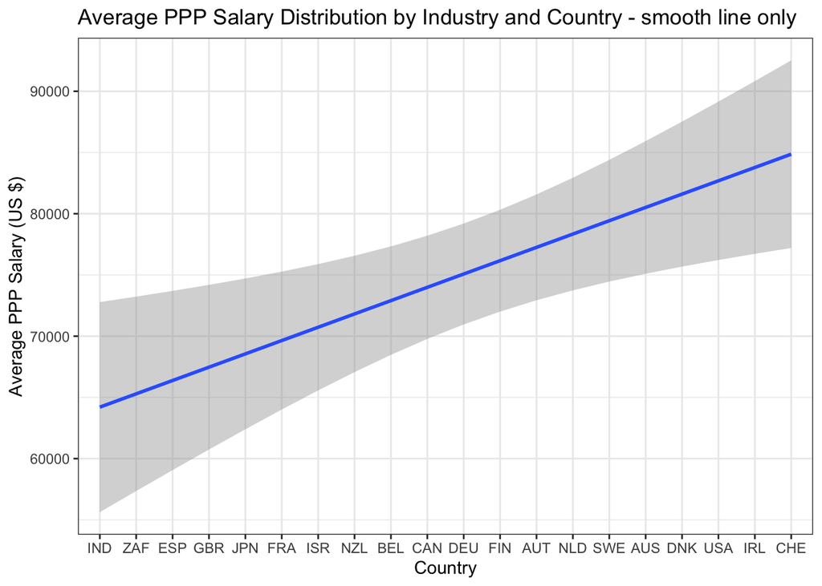

```r
# plot with only smooth line, x axis is ordered by GDP per capita
plot7%>%
    ggplot(aes(x=reorder(country, gdp),y=mean3,group=1,color=industry))+
  #geom_point()+
  geom_smooth(method = lm)+
  labs(title = "Average PPP Salary Distribution by Industry and Country - smooth line only",
       x="Country",
       y= "Average PPP Salary (US $)")+
   theme(axis.text=element_text(size=8),
        axis.title=element_text(size=10))+
  theme_bw()
```

On average, salaries worldwide fluctuate between $63,000 and $85,000, with Switzerland, Ireland and the USA having the highest average purchasing power adjusted salaries and India, South Africa and Spain having the lowest.

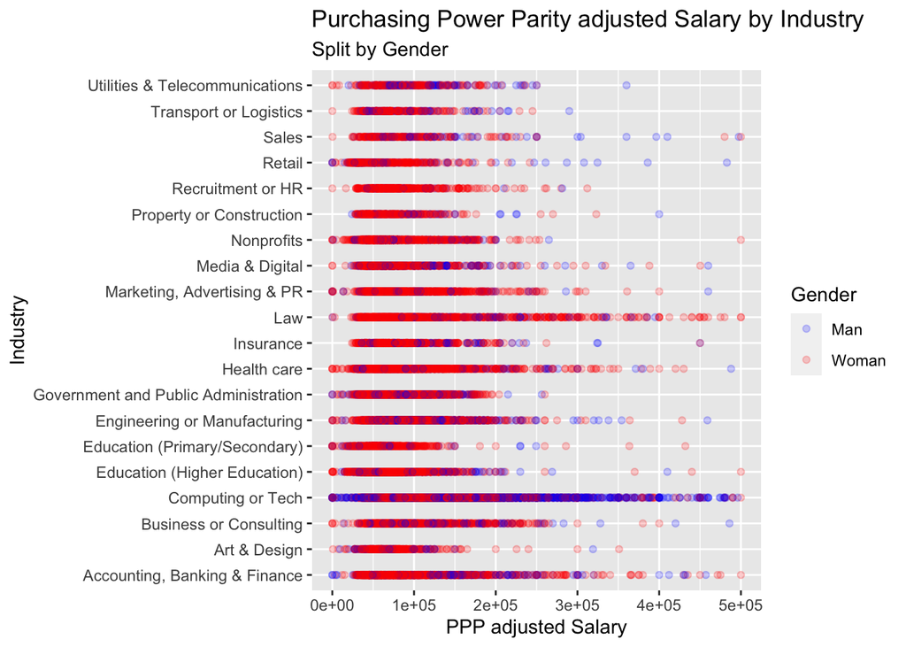

```r
ppp_data_clean %>%
  group_by(industry) %>%
  ggplot(aes(x=ppp_salary,y=industry,color=gender))+
  # facet_wrap(gender~.)+
  geom_point(alpha=0.2)+
  scale_color_manual(values = c("Man" = "blue", "Woman" = "red"))+
  labs(title = "Purchasing Power Parity adjusted Salary by Industry",
       subtitle = "Split by Gender",
       y= "Industry",
       x= "PPP adjusted Salary",
       colour= "Gender")+
  xlim(0, 500000)
```

Looking at the PPP adjusted salary for each industry, split by gender, seems to indicate a salary gap between genders, with men having higher salaries than woman in most industries. For instance, the industry with the most observations - Tech - seems to be overall heavily men-dominated, especially when looking at the right-hand side of the figure indicating that they also have higher salaries. This is not a surprising finding as studies show that there is less women then men in STEM, as there is a known “STEM gap” and social bias discourage women for pursuing careers in this field. We will investigate the gender gap in each industry for the United States in the next portion of our analysis.

## b. Focus on the United States

### Gender Gaps in the US

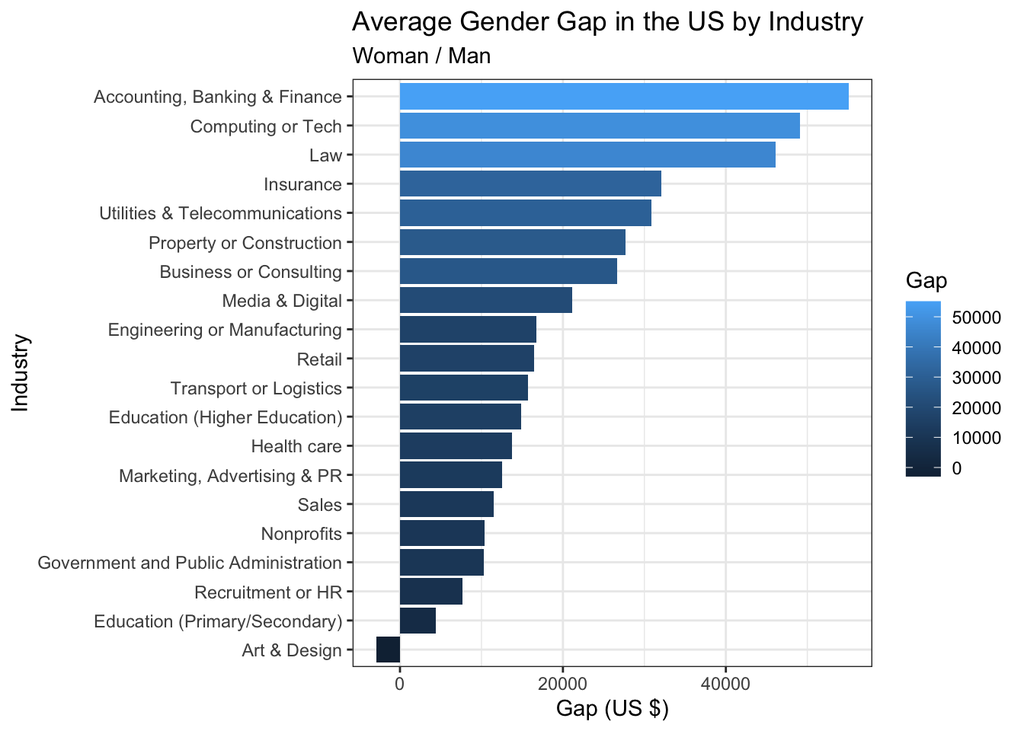

```r
# Average gender gap in the US by industry

plot1<-ppp_data_clean%>%
  select(gender,industry,ppp_salary,country)%>%
 filter(gender!="Non-binary")%>%
 filter(gender!="Other or prefer not to answer")%>%
 filter(gender!="Prefer not to answer")%>%
 filter(country =="USA")

plot2<-plot1%>%
 group_by(industry,gender)%>%
 summarise(mean=mean(ppp_salary))
plot1man<-plot2%>%
  filter(gender =="Man")

plot2woman<-plot2%>%
  filter(gender =="Woman")

plot<-left_join(plot1man,plot2woman,by = "industry")%>%
  mutate(gap=mean.x-mean.y)

plot%>%
  ggplot(aes(x=gap,y=reorder(industry, gap),group=1,fill = gap))+
  geom_bar(stat='identity')+
  labs(title = "Average Gender Gap in the US by Industry",
       subtitle = "Woman / Man",
       x="Gap (US $)",
       y= "Industry",
       fill = "Gap")+
  theme_bw()
```

### Average salary in the US by Industry

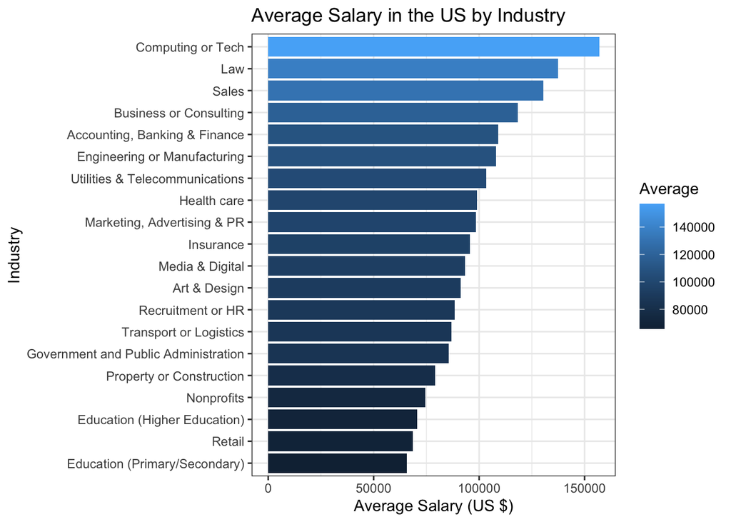

```r
# Average Salary in the US by industry

plot3<-plot1%>%
  select(industry,ppp_salary)%>%
group_by(industry)%>%
summarise(mean1=mean(ppp_salary))

  plot3%>%
  ggplot(aes(x=mean1,y=reorder(industry, mean1),group=1,fill = mean1))+
  geom_histogram(stat='identity')+
  labs(title = "Average Salary in the US by Industry",
       x="Average Salary (US $)",
       y= "Industry",
       fill= "Average")+
   theme(axis.text=element_text(size=8),
        axis.title=element_text(size=10),
        axis.text.x = element_blank()) +
    theme_bw()
```

The United States highest paying industries are the ones we would assume, with Tech, Law and Sales having the highest salaries. Those industries having a reputation of being male-dominated - especially tech and sales - in the United States, it will be interesting to investigate the gender differences in salaries.

### Race salary gaps in the US

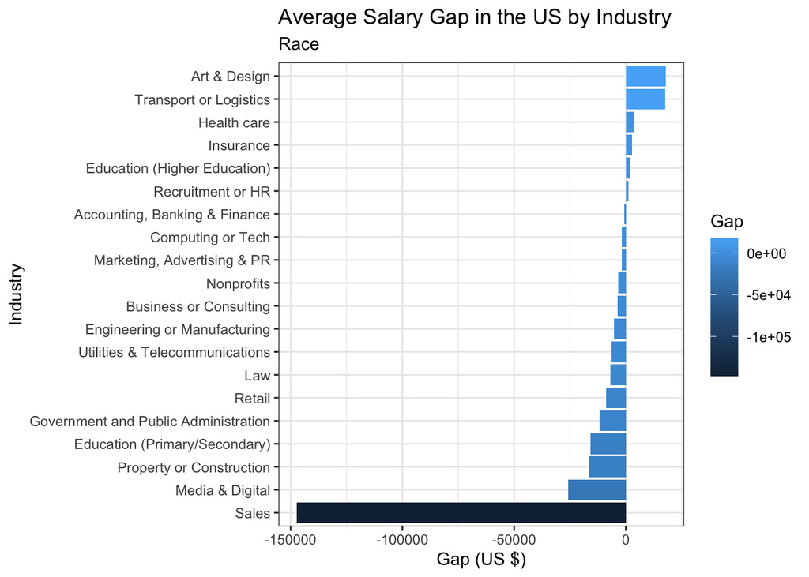

```r
plot1r<-ppp_data_final_clean%>%
  select(gender,industry,ppp_salary,country, race_filtered)%>%
  filter(country =="USA")

plot2r<-plot1r%>%
 group_by(industry,race_filtered)%>%
 summarise(mean=mean(ppp_salary))
plot1w<-plot2r%>%
  filter(race_filtered =="White")

plot2nw<-plot2r%>%
  filter(race_filtered =="Non White")

plotr<-left_join(plot1w,plot2nw,by = "industry")%>%
  mutate(gapr=mean.x-mean.y)

plotr%>%
  ggplot(aes(x=gapr,y=reorder(industry, gapr),group=1,fill = gapr))+
  geom_bar(stat='identity')+
  labs(title = "Average Salary Gap in the US by Industry",
       subtitle = "Race",
       x="Gap (US $)",
       y= "Industry",
       fill = "Gap")+
  theme_bw()
```

Based on our initial assumptions, public statistics and known political climate, we would assume that the salary gap in the US would benefit white people and disadvantage “non-white” people. However, as there were over 44 different race entries in the dataset, which we simplified to “non-white” and “white”, it looks as if people belonging to the stricly “white” category make less money on average than people who do not. This is not an extremely accurate conclusion as we would need to drill into a better classification of races to produce more relevant findings. Yet, this should be kept in mind when trying to predict salaries accurately with linear regression.

### Average salary in the US by education level

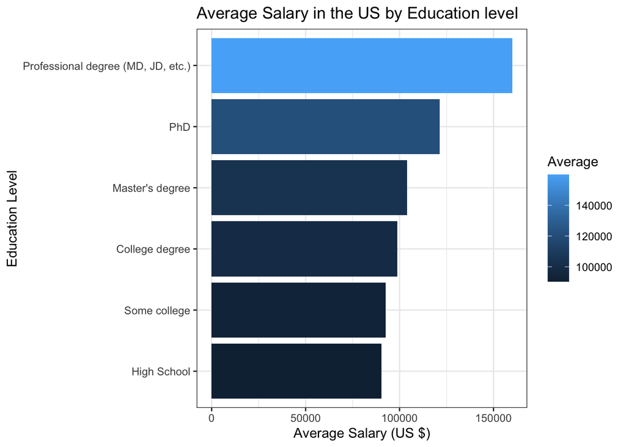

```r
# Average Salary in the US by educational level

plot4<-ppp_data_clean%>%
  drop_na(highest_level_of_education_completed)%>%
  drop_na(USD_exchange)%>%
  select(highest_level_of_education_completed,USD_exchange,country)%>%
  filter(country=="USA")%>%
  group_by(highest_level_of_education_completed)%>%
  summarise(mean2=mean(USD_exchange))

plot4 %>%
  ggplot(aes(x=mean2,y=reorder(highest_level_of_education_completed, mean2),group=1,fill=mean2))+
  geom_bar(stat='identity')+
  labs(title = "Average Salary in the US by Education level",
       x="Average Salary (US $)",
       y= "Education Level",
      fill = "Average")+
   theme(axis.text=element_text(size=8),
        axis.title=element_text(size=10))+
  theme_bw()
```

# 3. Regression

For our regression analysis, we are aiming to predict the total salary (annual salary and other monnetary compensation) for the USA, as this country has the highest number of observations and we are attempting to achieve a higher model accuracy.

```r
ppp_reg <- ppp_data_final_clean %>%
  filter(country== "USA")

model1  <- lm(total_salary ~ industry, data=ppp_reg)
mosaic::msummary(model1)
```

```
##                                              Estimate Std. Error t value
## (Intercept)                                  108566.2     2428.7  44.702
## industryArt & Design                         -17613.1     6071.6  -2.901
## industryBusiness or Consulting                 9100.6     4311.3   2.111
## industryComputing or Tech                     47767.5     2877.7  16.599
## industryEducation (Higher Education)         -37912.5     3172.8 -11.949
## industryEducation (Primary/Secondary)        -42642.1     4207.6 -10.135
## industryEngineering or Manufacturing           -677.5     3508.6  -0.193
## industryGovernment and Public Administration -22947.4     3450.5  -6.651
## industryHealth care                          -10543.7     3373.2  -3.126
## industryInsurance                            -12389.9     4993.1  -2.481
## industryLaw                                   28277.5     3847.9   7.349
## industryMarketing, Advertising & PR          -10304.3     3907.2  -2.637
## industryMedia & Digital                      -15254.3     4459.1  -3.421
## industryNonprofits                           -33916.8     3153.7 -10.755
## industryProperty or Construction             -29463.3     5854.5  -5.033
## industryRecruitment or HR                    -19989.4     5251.2  -3.807
## industryRetail                               -39964.1     5435.6  -7.352
## industrySales                                 22276.6     6535.1   3.409
## industryTransport or Logistics               -21997.9     6630.6  -3.318
## industryUtilities & Telecommunications        -5728.9     6242.1  -0.918
##                                              Pr(>|t|)
## (Intercept)                                   < 2e-16 ***
## industryArt & Design                         0.003726 **
## industryBusiness or Consulting               0.034796 *
## industryComputing or Tech                     < 2e-16 ***
## industryEducation (Higher Education)          < 2e-16 ***
## industryEducation (Primary/Secondary)         < 2e-16 ***
## industryEngineering or Manufacturing         0.846895
## industryGovernment and Public Administration 3.00e-11 ***
## industryHealth care                          0.001776 **
## industryInsurance                            0.013096 *
## industryLaw                                  2.09e-13 ***
## industryMarketing, Advertising & PR          0.008365 **
## industryMedia & Digital                      0.000625 ***
## industryNonprofits                            < 2e-16 ***
## industryProperty or Construction             4.89e-07 ***
## industryRecruitment or HR                    0.000141 ***
## industryRetail                               2.03e-13 ***
## industrySales                                0.000654 ***
## industryTransport or Logistics               0.000910 ***
## industryUtilities & Telecommunications       0.358744
##
## Residual standard error: 88340 on 18141 degrees of freedom
## Multiple R-squared:  0.1033, Adjusted R-squared:  0.1024
## F-statistic:   110 on 19 and 18141 DF,  p-value: < 2.2e-16
```

```r
confint(model1)
```

```
##                                                    2.5 %     97.5 %
## (Intercept)                                  103805.7518 113326.557
## industryArt & Design                         -29514.1325  -5712.120
## industryBusiness or Consulting                  650.0725  17551.095
## industryComputing or Tech                     42126.9402  53408.067
## industryEducation (Higher Education)         -44131.5520 -31693.391
## industryEducation (Primary/Secondary)        -50889.4857 -34394.811
## industryEngineering or Manufacturing          -7554.7207   6199.793
## industryGovernment and Public Administration -29710.6689 -16184.169
## industryHealth care                          -17155.4479  -3931.900
## industryInsurance                            -22176.9450  -2602.880
## industryLaw                                   20735.1708  35819.786
## industryMarketing, Advertising & PR          -17962.8725  -2645.808
## industryMedia & Digital                      -23994.4572  -6514.073
## industryNonprofits                           -40098.3589 -27735.223
## industryProperty or Construction             -40938.6035 -17987.916
## industryRecruitment or HR                    -30282.2015  -9696.557
## industryRetail                               -50618.3374 -29309.826
## industrySales                                  9467.1433  35086.011
## industryTransport or Logistics               -34994.4653  -9001.345
## industryUtilities & Telecommunications       -17964.1325   6506.248
```

```r
model2  <- lm(total_salary ~ industry + years_of_experience_in_field , data=ppp_reg)
mosaic::msummary(model2)
```

```
##                                              Estimate Std. Error t value
## (Intercept)                                     73490       3769  19.498
## industryArt & Design                           -15512       5922  -2.619
## industryBusiness or Consulting                  12809       4205   3.046
## industryComputing or Tech                       46792       2806  16.677
## industryEducation (Higher Education)           -40115       3095 -12.959
## industryEducation (Primary/Secondary)          -45822       4104 -11.166
## industryEngineering or Manufacturing            -1470       3420  -0.430
## industryGovernment and Public Administration   -25026       3365  -7.437
## industryHealth care                             -9477       3289  -2.882
## industryInsurance                              -13000       4868  -2.670
## industryLaw                                     28371       3753   7.560
## industryMarketing, Advertising & PR             -8337       3814  -2.186
## industryMedia & Digital                        -17469       4348  -4.017
## industryNonprofits                             -33545       3077 -10.900
## industryProperty or Construction               -26392       5709  -4.623
## industryRecruitment or HR                      -14812       5123  -2.891
## industryRetail                                 -39555       5299  -7.464
## industrySales                                   22563       6371   3.541
## industryTransport or Logistics                 -19353       6464  -2.994
## industryUtilities & Telecommunications          -8218       6086  -1.350
## years_of_experience_in_field11 - 20 years       54991       3298  16.677
## years_of_experience_in_field2 - 4 years         10548       3339   3.159
## years_of_experience_in_field21 - 30 years       71301       3877  18.392
## years_of_experience_in_field31 - 40 years       56240       6047   9.301
## years_of_experience_in_field41 years or more    38860      16562   2.346
## years_of_experience_in_field5-7 years           27519       3309   8.315
## years_of_experience_in_field8 - 10 years        40404       3381  11.951
##                                              Pr(>|t|)
## (Intercept)                                   < 2e-16 ***
## industryArt & Design                         0.008813 **
## industryBusiness or Consulting               0.002321 **
## industryComputing or Tech                     < 2e-16 ***
## industryEducation (Higher Education)          < 2e-16 ***
## industryEducation (Primary/Secondary)         < 2e-16 ***
## industryEngineering or Manufacturing         0.667458
## industryGovernment and Public Administration 1.07e-13 ***
## industryHealth care                          0.003960 **
## industryInsurance                            0.007585 **
## industryLaw                                  4.23e-14 ***
## industryMarketing, Advertising & PR          0.028824 *
## industryMedia & Digital                      5.91e-05 ***
## industryNonprofits                            < 2e-16 ***
## industryProperty or Construction             3.82e-06 ***
## industryRecruitment or HR                    0.003840 **
## industryRetail                               8.75e-14 ***
## industrySales                                0.000399 ***
## industryTransport or Logistics               0.002760 **
## industryUtilities & Telecommunications       0.176951
## years_of_experience_in_field11 - 20 years     < 2e-16 ***
## years_of_experience_in_field2 - 4 years      0.001583 **
## years_of_experience_in_field21 - 30 years     < 2e-16 ***
## years_of_experience_in_field31 - 40 years     < 2e-16 ***
## years_of_experience_in_field41 years or more 0.018969 *
## years_of_experience_in_field5-7 years         < 2e-16 ***
## years_of_experience_in_field8 - 10 years      < 2e-16 ***
##
## Residual standard error: 86110 on 18134 degrees of freedom
## Multiple R-squared:  0.1482, Adjusted R-squared:  0.147
## F-statistic: 121.4 on 26 and 18134 DF,  p-value: < 2.2e-16
```

```r
confint(model2)
```

```
##                                                   2.5 %      97.5 %
## (Intercept)                                   66102.635  80878.2861
## industryArt & Design                         -27119.446  -3904.8607
## industryBusiness or Consulting                 4566.625  21050.6544
## industryComputing or Tech                     41291.912  52291.0561
## industryEducation (Higher Education)         -46182.085 -34047.5023
## industryEducation (Primary/Secondary)        -53865.777 -37778.5929
## industryEngineering or Manufacturing          -8174.129   5234.9134
## industryGovernment and Public Administration -31622.113 -18430.7022
## industryHealth care                          -15923.732  -3030.9616
## industryInsurance                            -22541.625  -3457.4799
## industryLaw                                   21014.724  35726.8425
## industryMarketing, Advertising & PR          -15812.410   -861.7839
## industryMedia & Digital                      -25992.104  -8945.2303
## industryNonprofits                           -39577.151 -27513.0621
## industryProperty or Construction             -37582.349 -15200.9467
## industryRecruitment or HR                    -24853.463  -4770.8224
## industryRetail                               -49942.455 -29168.4221
## industrySales                                 10073.985  35051.2094
## industryTransport or Logistics               -32024.055  -6681.8466
## industryUtilities & Telecommunications       -20147.396   3711.5943
## years_of_experience_in_field11 - 20 years     48527.620  61454.5087
## years_of_experience_in_field2 - 4 years        4004.265  17092.4869
## years_of_experience_in_field21 - 30 years     63702.596  78900.2900
## years_of_experience_in_field31 - 40 years     44387.224  68092.4154
## years_of_experience_in_field41 years or more   6397.186  71323.0664
## years_of_experience_in_field5-7 years         21032.172  34005.6554
## years_of_experience_in_field8 - 10 years      33776.938  47030.4509
```

```r
model3 <- lm(total_salary ~ industry + years_of_experience_in_field + highest_level_of_education_completed, data=ppp_reg)
mosaic::msummary(model3)
```

```
##                                                                        Estimate
## (Intercept)                                                               71138
## industryArt & Design                                                     -15013
## industryBusiness or Consulting                                             8768
## industryComputing or Tech                                                 46803
## industryEducation (Higher Education)                                     -52239
## industryEducation (Primary/Secondary)                                    -53441
## industryEngineering or Manufacturing                                      -3772
## industryGovernment and Public Administration                             -34214
## industryHealth care                                                      -17230
## industryInsurance                                                        -13266
## industryLaw                                                              -11693
## industryMarketing, Advertising & PR                                       -7144
## industryMedia & Digital                                                  -17257
## industryNonprofits                                                       -37952
## industryProperty or Construction                                         -22430
## industryRecruitment or HR                                                -13722
## industryRetail                                                           -33592
## industrySales                                                             25479
## industryTransport or Logistics                                           -15043
## industryUtilities & Telecommunications                                    -7190
## years_of_experience_in_field11 - 20 years                                 52986
## years_of_experience_in_field2 - 4 years                                    9448
## years_of_experience_in_field21 - 30 years                                 70724
## years_of_experience_in_field31 - 40 years                                 58164
## years_of_experience_in_field41 years or more                              44508
## years_of_experience_in_field5-7 years                                     25626
## years_of_experience_in_field8 - 10 years                                  37493
## highest_level_of_education_completedHigh School                          -18210
## highest_level_of_education_completedMaster's degree                       14716
## highest_level_of_education_completedPhD                                   41025
## highest_level_of_education_completedProfessional degree (MD, JD, etc.)    68632
## highest_level_of_education_completedSome college                         -15716
##                                                                        Std. Error
## (Intercept)                                                                  3732
## industryArt & Design                                                         5822
## industryBusiness or Consulting                                               4137
## industryComputing or Tech                                                    2759
## industryEducation (Higher Education)                                         3130
## industryEducation (Primary/Secondary)                                        4063
```

[output cut: 114 more lines]

```
## years_of_experience_in_field2 - 4 years                                **
## years_of_experience_in_field21 - 30 years                              ***
## years_of_experience_in_field31 - 40 years                              ***
## years_of_experience_in_field41 years or more                           **
## years_of_experience_in_field5-7 years                                  ***
## years_of_experience_in_field8 - 10 years                               ***
## highest_level_of_education_completedHigh School                        ***
## highest_level_of_education_completedMaster's degree                    ***
## highest_level_of_education_completedPhD                                ***
## highest_level_of_education_completedProfessional degree (MD, JD, etc.) ***
## highest_level_of_education_completedSome college                       ***
##
## Residual standard error: 84590 on 18129 degrees of freedom
## Multiple R-squared:  0.1782, Adjusted R-squared:  0.1768
## F-statistic: 126.9 on 31 and 18129 DF,  p-value: < 2.2e-16
```

```r
confint(model3)
```

```
##                                                                              2.5 %
## (Intercept)                                                             63822.0730
## industryArt & Design                                                   -26424.8987
## industryBusiness or Consulting                                            659.1326
## industryComputing or Tech                                               41394.8832
## industryEducation (Higher Education)                                   -58373.5431
## industryEducation (Primary/Secondary)                                  -61404.8189
## industryEngineering or Manufacturing                                   -10373.5369
## industryGovernment and Public Administration                           -40753.4734
## industryHealth care                                                    -23593.2363
## industryInsurance                                                      -22641.8683
## industryLaw                                                            -19928.1339
## industryMarketing, Advertising & PR                                    -14500.4370
## industryMedia & Digital                                                -25640.4847
## industryNonprofits                                                     -43904.8734
## industryProperty or Construction                                       -33437.5144
## industryRecruitment or HR                                              -23588.8268
## industryRetail                                                         -43826.9023
## industrySales                                                           13205.3567
## industryTransport or Logistics                                         -27505.5761
## industryUtilities & Telecommunications                                 -18911.7595
## years_of_experience_in_field11 - 20 years                               46621.9738
## years_of_experience_in_field2 - 4 years                                  3016.2809
## years_of_experience_in_field21 - 30 years                               63242.2518
## years_of_experience_in_field31 - 40 years                               46507.6279
## years_of_experience_in_field41 years or more                            12598.5545
## years_of_experience_in_field5-7 years                                   19245.2667
## years_of_experience_in_field8 - 10 years                                30968.4338
## highest_level_of_education_completedHigh School                        -28229.1185
## highest_level_of_education_completedMaster's degree                     11807.5905
## highest_level_of_education_completedPhD                                 34830.0024
## highest_level_of_education_completedProfessional degree (MD, JD, etc.)  61908.9480
## highest_level_of_education_completedSome college                       -20902.8497
##                                                                             97.5 %
## (Intercept)                                                             78452.9118
## industryArt & Design                                                    -3601.3833
## industryBusiness or Consulting                                          16876.2647
## industryComputing or Tech                                               52210.5614
## industryEducation (Higher Education)                                   -46103.6435
## industryEducation (Primary/Secondary)                                  -45476.6572
```

[output cut: 11 more lines]

```
## industrySales                                                           37752.1763
## industryTransport or Logistics                                          -2580.6208
## industryUtilities & Telecommunications                                   4532.7980
## years_of_experience_in_field11 - 20 years                               59350.9026
## years_of_experience_in_field2 - 4 years                                 15880.3299
## years_of_experience_in_field21 - 30 years                               78204.8351
## years_of_experience_in_field31 - 40 years                               69821.0208
## years_of_experience_in_field41 years or more                            76417.4503
## years_of_experience_in_field5-7 years                                   32006.7440
## years_of_experience_in_field8 - 10 years                                44017.1853
## highest_level_of_education_completedHigh School                         -8190.3432
## highest_level_of_education_completedMaster's degree                     17623.9608
## highest_level_of_education_completedPhD                                 47220.2484
## highest_level_of_education_completedProfessional degree (MD, JD, etc.)  75355.7762
## highest_level_of_education_completedSome college                       -10530.0163
```

```r
model4 <- lm(total_salary ~ industry + years_of_experience_in_field + highest_level_of_education_completed + gender, data=ppp_reg)
mosaic::msummary(model4)
```

```
##                                                                        Estimate
## (Intercept)                                                               95270
## industryArt & Design                                                     -14925
## industryBusiness or Consulting                                             8618
## industryComputing or Tech                                                 39706
## industryEducation (Higher Education)                                     -51459
## industryEducation (Primary/Secondary)                                    -51801
## industryEngineering or Manufacturing                                      -6536
## industryGovernment and Public Administration                             -33784
## industryHealth care                                                      -15636
## industryInsurance                                                        -13137
## industryLaw                                                              -10224
## industryMarketing, Advertising & PR                                       -6435
## industryMedia & Digital                                                  -18281
## industryNonprofits                                                       -36436
## industryProperty or Construction                                         -21975
## industryRecruitment or HR                                                -11579
## industryRetail                                                           -33547
## industrySales                                                             24079
## industryTransport or Logistics                                           -16547
## industryUtilities & Telecommunications                                    -9162
## years_of_experience_in_field11 - 20 years                                 50857
## years_of_experience_in_field2 - 4 years                                    8914
## years_of_experience_in_field21 - 30 years                                 67292
## years_of_experience_in_field31 - 40 years                                 55814
## years_of_experience_in_field41 years or more                              37701
## years_of_experience_in_field5-7 years                                     24619
## years_of_experience_in_field8 - 10 years                                  36332
## highest_level_of_education_completedHigh School                          -22642
## highest_level_of_education_completedMaster's degree                       15302
## highest_level_of_education_completedPhD                                   40660
## highest_level_of_education_completedProfessional degree (MD, JD, etc.)    68074
## highest_level_of_education_completedSome college                         -17334
## genderWoman                                                              -26779
##                                                                        Std. Error
## (Intercept)                                                                  4009
## industryArt & Design                                                         5782
## industryBusiness or Consulting                                               4109
## industryComputing or Tech                                                    2777
## industryEducation (Higher Education)                                         3109
```

[output cut: 119 more lines]

```
## years_of_experience_in_field21 - 30 years                              ***
## years_of_experience_in_field31 - 40 years                              ***
## years_of_experience_in_field41 years or more                           *
## years_of_experience_in_field5-7 years                                  ***
## years_of_experience_in_field8 - 10 years                               ***
## highest_level_of_education_completedHigh School                        ***
## highest_level_of_education_completedMaster's degree                    ***
## highest_level_of_education_completedPhD                                ***
## highest_level_of_education_completedProfessional degree (MD, JD, etc.) ***
## highest_level_of_education_completedSome college                       ***
## genderWoman                                                            ***
##
## Residual standard error: 84020 on 18128 degrees of freedom
## Multiple R-squared:  0.1894, Adjusted R-squared:  0.188
## F-statistic: 132.4 on 32 and 18128 DF,  p-value: < 2.2e-16
```

```r
confint(model4)
```

```
##                                                                             2.5 %
## (Intercept)                                                             87412.252
## industryArt & Design                                                   -26259.240
## industryBusiness or Consulting                                            564.378
## industryComputing or Tech                                               34263.826
## industryEducation (Higher Education)                                   -57553.093
## industryEducation (Primary/Secondary)                                  -59713.410
## industryEngineering or Manufacturing                                   -13101.475
## industryGovernment and Public Administration                           -40279.774
## industryHealth care                                                    -21958.620
## industryInsurance                                                      -22449.898
## industryLaw                                                            -18404.755
## industryMarketing, Advertising & PR                                    -13742.839
## industryMedia & Digital                                                -26607.983
## industryNonprofits                                                     -42351.208
## industryProperty or Construction                                       -32908.124
## industryRecruitment or HR                                              -21382.287
## industryRetail                                                         -43712.814
## industrySales                                                           11887.557
## industryTransport or Logistics                                         -28926.290
## industryUtilities & Telecommunications                                 -20807.029
## years_of_experience_in_field11 - 20 years                               44530.447
## years_of_experience_in_field2 - 4 years                                  2525.101
## years_of_experience_in_field21 - 30 years                               59849.055
## years_of_experience_in_field31 - 40 years                               44232.641
## years_of_experience_in_field41 years or more                             5997.298
## years_of_experience_in_field5-7 years                                   18280.269
## years_of_experience_in_field8 - 10 years                                29850.256
## highest_level_of_education_completedHigh School                        -32608.671
## highest_level_of_education_completedMaster's degree                     12412.948
## highest_level_of_education_completedPhD                                 34506.481
## highest_level_of_education_completedProfessional degree (MD, JD, etc.)  61396.369
## highest_level_of_education_completedSome college                       -22489.163
## genderWoman                                                            -30099.216
##                                                                              97.5 %
## (Intercept)                                                            103127.37042
## industryArt & Design                                                    -3590.83840
## industryBusiness or Consulting                                          16671.33019
## industryComputing or Tech                                               45149.13922
## industryEducation (Higher Education)                                   -45365.05579
```

[output cut: 13 more lines]

```
## industryTransport or Logistics                                          -4167.93310
## industryUtilities & Telecommunications                                   2483.31798
## years_of_experience_in_field11 - 20 years                               57183.88068
## years_of_experience_in_field2 - 4 years                                 15302.40500
## years_of_experience_in_field21 - 30 years                               74734.28494
## years_of_experience_in_field31 - 40 years                               67394.91387
## years_of_experience_in_field41 years or more                            69404.90273
## years_of_experience_in_field5-7 years                                   30957.46979
## years_of_experience_in_field8 - 10 years                                42813.51556
## highest_level_of_education_completedHigh School                        -12675.77118
## highest_level_of_education_completedMaster's degree                     18191.61657
## highest_level_of_education_completedPhD                                 46812.84778
## highest_level_of_education_completedProfessional degree (MD, JD, etc.)  74752.51969
## highest_level_of_education_completedSome college                       -12179.02520
## genderWoman                                                            -23459.30933
```

```r
model5 <- lm(total_salary ~ industry + years_of_experience_in_field + highest_level_of_education_completed + gender+ overall_years_of_professional_experience, data=ppp_reg)
mosaic::msummary(model5)
```

```
##                                                                        Estimate
## (Intercept)                                                               98391
## industryArt & Design                                                     -15412
## industryBusiness or Consulting                                             8482
## industryComputing or Tech                                                 39501
## industryEducation (Higher Education)                                     -51646
## industryEducation (Primary/Secondary)                                    -52094
## industryEngineering or Manufacturing                                      -6605
## industryGovernment and Public Administration                             -33683
## industryHealth care                                                      -15580
## industryInsurance                                                        -13186
## industryLaw                                                              -10196
## industryMarketing, Advertising & PR                                       -6783
## industryMedia & Digital                                                  -18187
## industryNonprofits                                                       -36674
## industryProperty or Construction                                         -22267
## industryRecruitment or HR                                                -11810
## industryRetail                                                           -33711
## industrySales                                                             23972
## industryTransport or Logistics                                           -16565
## industryUtilities & Telecommunications                                    -8914
## years_of_experience_in_field11 - 20 years                                 51086
## years_of_experience_in_field2 - 4 years                                   10381
## years_of_experience_in_field21 - 30 years                                 75576
## years_of_experience_in_field31 - 40 years                                 64832
## years_of_experience_in_field41 years or more                              52046
## years_of_experience_in_field5-7 years                                     24342
## years_of_experience_in_field8 - 10 years                                  35308
## highest_level_of_education_completedHigh School                          -22020
## highest_level_of_education_completedMaster's degree                       15079
## highest_level_of_education_completedPhD                                   40528
## highest_level_of_education_completedProfessional degree (MD, JD, etc.)    67698
## highest_level_of_education_completedSome college                         -16646
## genderWoman                                                              -26568
## overall_years_of_professional_experience11 - 20 years                     -1034
## overall_years_of_professional_experience2 - 4 years                       -7250
## overall_years_of_professional_experience21 - 30 years                    -11396
## overall_years_of_professional_experience31 - 40 years                    -11420
## overall_years_of_professional_experience41 years or more                 -21498
## overall_years_of_professional_experience5-7 years                         -3496
```

[output cut: 154 more lines]

```
## highest_level_of_education_completedPhD                                ***
## highest_level_of_education_completedProfessional degree (MD, JD, etc.) ***
## highest_level_of_education_completedSome college                       ***
## genderWoman                                                            ***
## overall_years_of_professional_experience11 - 20 years
## overall_years_of_professional_experience2 - 4 years
## overall_years_of_professional_experience21 - 30 years                  .
## overall_years_of_professional_experience31 - 40 years
## overall_years_of_professional_experience41 years or more               .
## overall_years_of_professional_experience5-7 years
## overall_years_of_professional_experience8 - 10 years
##
## Residual standard error: 83980 on 18121 degrees of freedom
## Multiple R-squared:  0.1905, Adjusted R-squared:  0.1888
## F-statistic: 109.4 on 39 and 18121 DF,  p-value: < 2.2e-16
```

```r
confint(model5)
```

```
##                                                                              2.5 %
## (Intercept)                                                             87060.0282
## industryArt & Design                                                   -26747.8811
## industryBusiness or Consulting                                            428.8817
## industryComputing or Tech                                               34058.0896
## industryEducation (Higher Education)                                   -57739.0627
## industryEducation (Primary/Secondary)                                  -60004.3196
## industryEngineering or Manufacturing                                   -13177.5712
## industryGovernment and Public Administration                           -40176.3886
## industryHealth care                                                    -21899.6312
## industryInsurance                                                      -22496.1618
## industryLaw                                                            -18376.5786
## industryMarketing, Advertising & PR                                    -14093.1446
## industryMedia & Digital                                                -26516.3227
## industryNonprofits                                                     -42588.5364
## industryProperty or Construction                                       -33204.1165
## industryRecruitment or HR                                              -21610.4433
## industryRetail                                                         -43876.6760
## industrySales                                                           11783.9540
## industryTransport or Logistics                                         -28946.1040
## industryUtilities & Telecommunications                                 -20558.0444
## years_of_experience_in_field11 - 20 years                               43095.0549
## years_of_experience_in_field2 - 4 years                                  2986.5563
## years_of_experience_in_field21 - 30 years                               65896.1939
## years_of_experience_in_field31 - 40 years                               49980.4399
## years_of_experience_in_field41 years or more                            16565.8634
## years_of_experience_in_field5-7 years                                   16712.1746
## years_of_experience_in_field8 - 10 years                                27399.6140
## highest_level_of_education_completedHigh School                        -31993.1702
## highest_level_of_education_completedMaster's degree                     12183.6323
## highest_level_of_education_completedPhD                                 34376.1766
## highest_level_of_education_completedProfessional degree (MD, JD, etc.)  61019.3278
## highest_level_of_education_completedSome college                       -21837.2375
## genderWoman                                                            -29889.7257
## overall_years_of_professional_experience11 - 20 years                  -13444.9945
## overall_years_of_professional_experience2 - 4 years                    -19606.8808
## overall_years_of_professional_experience21 - 30 years                  -24430.3498
## overall_years_of_professional_experience31 - 40 years                  -26533.1081
## overall_years_of_professional_experience41 years or more               -45330.1801
## overall_years_of_professional_experience5-7 years                      -15878.8489
```

[output cut: 27 more lines]

```
## years_of_experience_in_field5-7 years                                   31972.10789
## years_of_experience_in_field8 - 10 years                                43216.87674
## highest_level_of_education_completedHigh School                        -12046.28011
## highest_level_of_education_completedMaster's degree                     17974.10052
## highest_level_of_education_completedPhD                                 46680.00012
## highest_level_of_education_completedProfessional degree (MD, JD, etc.)  74377.38915
## highest_level_of_education_completedSome college                       -11455.85347
## genderWoman                                                            -23246.10573
## overall_years_of_professional_experience11 - 20 years                   11377.54779
## overall_years_of_professional_experience2 - 4 years                      5106.34865
## overall_years_of_professional_experience21 - 30 years                    1637.40666
## overall_years_of_professional_experience31 - 40 years                    3692.21638
## overall_years_of_professional_experience41 years or more                 2334.16693
## overall_years_of_professional_experience5-7 years                        8887.53851
## overall_years_of_professional_experience8 - 10 years                    10791.80554
```

```r
model6 <- lm(total_salary ~ industry + years_of_experience_in_field + highest_level_of_education_completed + gender+ overall_years_of_professional_experience + race_filtered , data=ppp_reg)
mosaic::msummary(model6)
```

```
##                                                                        Estimate
## (Intercept)                                                            106768.3
## industryArt & Design                                                   -15560.0
## industryBusiness or Consulting                                           8410.8
## industryComputing or Tech                                               39289.2
## industryEducation (Higher Education)                                   -51055.9
## industryEducation (Primary/Secondary)                                  -51343.3
## industryEngineering or Manufacturing                                    -6496.1
## industryGovernment and Public Administration                           -33468.1
## industryHealth care                                                    -15445.1
## industryInsurance                                                      -12559.2
## industryLaw                                                             -9868.5
## industryMarketing, Advertising & PR                                     -6375.6
## industryMedia & Digital                                                -18151.6
## industryNonprofits                                                     -36492.4
## industryProperty or Construction                                       -21879.9
## industryRecruitment or HR                                              -12330.5
## industryRetail                                                         -33123.8
## industrySales                                                           24033.4
## industryTransport or Logistics                                         -16350.8
## industryUtilities & Telecommunications                                  -8729.2
## years_of_experience_in_field11 - 20 years                               51991.7
## years_of_experience_in_field2 - 4 years                                 10846.1
## years_of_experience_in_field21 - 30 years                               76483.2
## years_of_experience_in_field31 - 40 years                               65888.0
## years_of_experience_in_field41 years or more                            52115.0
## years_of_experience_in_field5-7 years                                   24932.2
## years_of_experience_in_field8 - 10 years                                36048.4
## highest_level_of_education_completedHigh School                        -22229.7
## highest_level_of_education_completedMaster's degree                     15138.5
## highest_level_of_education_completedPhD                                 40955.6
## highest_level_of_education_completedProfessional degree (MD, JD, etc.)  67541.3
## highest_level_of_education_completedSome college                       -16809.8
## genderWoman                                                            -26520.9
## overall_years_of_professional_experience11 - 20 years                     689.2
## overall_years_of_professional_experience2 - 4 years                     -6767.8
## overall_years_of_professional_experience21 - 30 years                   -9341.4
## overall_years_of_professional_experience31 - 40 years                   -9137.3
## overall_years_of_professional_experience41 years or more               -18520.5
## overall_years_of_professional_experience5-7 years                       -2338.1
```

[output cut: 159 more lines]

```
## highest_level_of_education_completedProfessional degree (MD, JD, etc.) ***
## highest_level_of_education_completedSome college                       ***
## genderWoman                                                            ***
## overall_years_of_professional_experience11 - 20 years
## overall_years_of_professional_experience2 - 4 years
## overall_years_of_professional_experience21 - 30 years
## overall_years_of_professional_experience31 - 40 years
## overall_years_of_professional_experience41 years or more
## overall_years_of_professional_experience5-7 years
## overall_years_of_professional_experience8 - 10 years
## race_filteredWhite                                                     ***
##
## Residual standard error: 83870 on 18120 degrees of freedom
## Multiple R-squared:  0.1927, Adjusted R-squared:  0.1909
## F-statistic: 108.1 on 40 and 18120 DF,  p-value: < 2.2e-16
```

```r
confint(model6)
```

```
##                                                                              2.5 %
## (Intercept)                                                             95207.2112
## industryArt & Design                                                   -26880.9222
## industryBusiness or Consulting                                            368.1245
## industryComputing or Tech                                               33853.5146
## industryEducation (Higher Education)                                   -57143.0280
## industryEducation (Primary/Secondary)                                  -59246.1070
## industryEngineering or Manufacturing                                   -13060.4910
## industryGovernment and Public Administration                           -39953.3895
## industryHealth care                                                    -21757.0219
## industryInsurance                                                      -21858.7227
## industryLaw                                                            -18039.2619
## industryMarketing, Advertising & PR                                    -13676.7490
## industryMedia & Digital                                                -26470.5632
## industryNonprofits                                                     -42399.7207
## industryProperty or Construction                                       -32803.4816
## industryRecruitment or HR                                              -22119.0567
## industryRetail                                                         -43277.2943
## industrySales                                                           11861.2182
## industryTransport or Logistics                                         -28715.6798
## industryUtilities & Telecommunications                                 -20358.0729
## years_of_experience_in_field11 - 20 years                               44006.9245
## years_of_experience_in_field2 - 4 years                                  3459.7515
## years_of_experience_in_field21 - 30 years                               66812.4584
## years_of_experience_in_field31 - 40 years                               51053.2356
## years_of_experience_in_field41 years or more                            16681.0378
## years_of_experience_in_field5-7 years                                   17310.3500
## years_of_experience_in_field8 - 10 years                                28147.2983
## highest_level_of_education_completedHigh School                        -32190.3635
## highest_level_of_education_completedMaster's degree                     12247.0012
## highest_level_of_education_completedPhD                                 34810.4816
## highest_level_of_education_completedProfessional degree (MD, JD, etc.)  60870.7679
## highest_level_of_education_completedSome college                       -21993.9822
## genderWoman                                                            -29838.4657
## overall_years_of_professional_experience11 - 20 years                  -11715.5153
## overall_years_of_professional_experience2 - 4 years                    -19109.1066
## overall_years_of_professional_experience21 - 30 years                  -22371.2973
## overall_years_of_professional_experience31 - 40 years                  -24244.0263
## overall_years_of_professional_experience41 years or more               -42336.5752
## overall_years_of_professional_experience5-7 years                      -14709.5002
```

[output cut: 29 more lines]

```
## years_of_experience_in_field8 - 10 years                                43949.52560
## highest_level_of_education_completedHigh School                        -12269.05161
## highest_level_of_education_completedMaster's degree                     18030.03989
## highest_level_of_education_completedPhD                                 47100.68053
## highest_level_of_education_completedProfessional degree (MD, JD, etc.)  74211.75870
## highest_level_of_education_completedSome college                       -11625.68413
## genderWoman                                                            -23203.42938
## overall_years_of_professional_experience11 - 20 years                   13093.83592
## overall_years_of_professional_experience2 - 4 years                      5573.49875
## overall_years_of_professional_experience21 - 30 years                    3688.41491
## overall_years_of_professional_experience31 - 40 years                    5969.51934
## overall_years_of_professional_experience41 years or more                 5295.48405
## overall_years_of_professional_experience5-7 years                       10033.32447
## overall_years_of_professional_experience8 - 10 years                    12122.68981
## race_filteredWhite                                                      -8994.08567
```

```r
huxtable::huxreg(model1, model2, model3, model4, model5, model6)
```

|  | (1) | (2) | (3) | (4) | (5) | (6) |
| --- | --- | --- | --- | --- | --- | --- |
| (Intercept) | 108566.154 *** | 73490.461 *** | 71137.492 *** | 95269.811 *** | 98391.345 *** | 106768.254 *** |
|  | (2428.659) | (3769.116) | (3732.176) | (4008.765) | (5781.004) | (5898.206) |
| industryArt & Design | -17613.126 ** | -15512.153 ** | -15013.141 ** | -14925.039 ** | -15412.321 ** | -15560.022 ** |
|  | (6071.648) | (5921.802) | (5822.044) | (5782.476) | (5783.169) | (5775.690) |
| industryBusiness or Consulting | 9100.584 * | 12808.639 ** | 8767.699 * | 8617.854 * | 8482.035 * | 8410.834 * |
|  | (4311.277) | (4204.906) | (4136.823) | (4108.718) | (4108.553) | (4103.224) |
| industryComputing or Tech | 47767.504 *** | 46791.484 *** | 46802.722 *** | 39706.483 *** | 39500.552 *** | 39289.229 *** |
|  | (2877.699) | (2805.768) | (2758.968) | (2776.731) | (2776.632) | (2773.189) |
| industryEducation (Higher Education) | -37912.472 *** | -40114.794 *** | -52238.593 *** | -51459.075 *** | -51646.274 *** | -51055.877 *** |
|  | (3172.847) | (3095.407) | (3129.925) | (3109.043) | (3108.415) | (3105.539) |
| industryEducation (Primary/Secondary) | -42642.148 *** | -45822.185 *** | -53440.738 *** | -51800.846 *** | -52094.060 *** | -51343.289 *** |
|  | (4207.622) | (4103.675) | (4063.110) | (4036.827) | (4035.651) | (4031.855) |
| industryEngineering or Manufacturing | -677.464 | -1469.608 | -3771.812 | -6535.672 | -6604.659 * | -6496.052 |
|  | (3508.635) | (3420.509) | (3368.064) | (3349.737) | (3353.364) | (3349.042) |
| industryGovernment and Public Administration | -22947.419 *** | -25026.408 *** | -34213.553 *** | -33784.085 *** | -33682.907 *** | -33468.066 *** |
|  | (3450.471) | (3364.993) | (3336.533) | (3313.967) | (3312.840) | (3308.678) |
| industryHealth care | -10543.674 ** | -9477.347 ** | -17230.520 *** | -15636.059 *** | -15579.576 *** | -15445.069 *** |
|  | (3373.191) | (3288.813) | (3246.127) | (3225.641) | (3224.362) | (3220.228) |
| industryInsurance | -12389.913 * | -12999.553 ** | -13265.517 ** | -13137.262 ** | -13186.188 ** | -12559.167 ** |
|  | (4993.142) | (4868.169) | (4783.621) | (4751.115) | (4749.757) | (4744.441) |
| industryLaw | 28277.478 *** | 28370.783 *** | -11693.139 ** | -10223.701 * | -10195.659 * | -9868.455 * |
|  | (3847.930) | (3752.910) | (4201.325) | (4173.805) | (4173.736) | (4168.577) |
| industryMarketing, Advertising & PR | -10304.340 ** | -8337.097 * | -7143.541 | -6435.418 | -6783.407 | -6375.606 |
|  | (3907.226) | (3813.751) | (3753.337) | (3728.096) | (3729.277) | (3724.893) |
| industryMedia & Digital | -15254.265 *** | -17468.667 *** | -17257.208 *** | -18280.719 *** | -18186.582 *** | -18151.645 *** |
|  | (4459.066) | (4348.482) | (4276.975) | (4248.399) | (4249.662) | (4244.140) |
| industryNonprofits | -33916.791 *** | -33545.107 *** | -37952.395 *** | -36436.199 *** | -36673.762 *** | -36492.413 *** |
|  | (3153.709) | (3077.425) | (3036.832) | (3017.716) | (3017.596) | (3013.786) |
| industryProperty or Construction | -29463.260 *** | -26391.648 *** | -22429.454 *** | -21974.736 *** | -22266.897 *** | -21879.934 *** |
|  | (5854.484) | (5709.265) | (5616.086) | (5577.989) | (5579.944) | (5572.969) |

[output cut: 57 more lines]

To begin with, we run a linear regression model while only including the variable industry which we have cleaned to only include the top 20 industries in our dataframe (which all account for more than 1% of observations in our dataframe). Upon running the regression, we achieve an R squared of 10.33% which means that the predictor variable industry explains 10.33% of our dependent/response variable “total_salary”. We can also look at the residual standard error to evaluate how well the linear regression model fits the data. This measure shows the average amount that the real values of total salary differ from the predictions our regression line provides. Our residual standard error of 88340 indicates that on average the actual total salary of a person in the US deviates from our regression line by approximately 88340 dollars. While looking at our regression table, we can distinguish which variables are statistically significant by looking at the p-value and the indication of stars after the variables. Furthermore, the t-value shows how many standard deviations out coefficient estimate is situated compared to 0. If our t-stat is more than 2, it is a strong indication that we can reject the null hypothesis (there is no salary difference between different industries) and indicate a relationship between the two variables. As we can see, our model indicates that most industries are statistically significant in terms of our model, showcased by for example the variable ‘industryComputing or Tech’ with a p-value smaller than 0.01, indicating that someone in the Computing or Tech industry would earn on average 47767.5 dollars more than someone in the ‘control’ industry which is Accounting, Banking & Finance while someone in the Art & Design industry would earn on average 17613.1 dollars less than someone in Accounting, Banking & Finance. However, for the Engineering or Manufacturing industry we observe a t-value of less than 2 and a large p-value of 0.84, indicating no statistical significance that there is a difference between the total salary for a person in Accounting, Banking & Finance and Engineering or Manufacturing. The intercept of 108566.2 dollars indicates the total salary with no industry. Furthermore, we can analyse the 95% confidence interval for each industry to see where 95% of the predicted total salary observations lie in terms of the baseline. For example, for the Computing or Tech industry 95% of total salaries differ from the baseline industry Accounting, Banking & Finance’s total salary in the range of 42126.9402 to 53408.067. All in all, our simplistic model 1 is not very good at predicting total salary, meaning that we should add other variables to increase accuracy. Consequently, the R squared will increase while running a multiple regression, as more variables are included in the model. The adjusted R squared solves this problem by adjusting for the number of considered variables.